# Notebook 15 – Solutions

## Getting Started

Before running this notebook, select “Session > Restart R and Clear Output” in the menu above to start a new R session. This will clear any old data sets and give us a blank slate to start with.

We have one final extra package to install, which will allow us to show map data in R. Uncomment the following line, run the code, and re-comment the line before proceeding.

```r
#remotes::install_github("statsmaths/ggmaptile", upgrade = "never")
```

## Chicago Data

### Load the Data

For the last part of the semester we will be looking at a number of open data sets from the City of Chicago. We will load in several here:

```r
comarea <- read_sf(file.path("data", "chicago_community_areas.geojson"))
ziparea <- read_sf(file.path("data", "zip_codes.geojson"))
socio <- read_csv(file.path("data", "census_socioeconomic.csv"))
medical <- read_csv(file.path("data", "chicago_medical_examiner_cases.csv.gz"))
```

Today, our focus on the spatial components of the dataset. The spatial data contains information about zip codes and community areas. Specifically, we will look at a set of records by the Medican Examiner’s office showing deaths they have investigated:

```r
medical
```

```
## # A tibble: 34,566 x 14
##    date_incident_iso   date_death_iso      primary_cause   age gender race
##    <dttm>              <dttm>              <chr>         <dbl> <chr>  <chr>
##  1 2015-01-01 03:25:00 2015-01-01 03:10:00 HYPERTENSIVE…    50 Male   Black
##  2 2014-12-08 18:37:00 2015-01-01 07:15:00 COMPLICATION…    89 Female White
##  3 2014-12-21 23:13:00 2015-01-01 08:45:00 COMPLICATION…    67 Male   Black
##  4 2015-01-01 09:07:00 2015-01-01 09:20:00 COMPLICATION…    31 Male   White
##  5 2015-01-01 09:54:00 2015-01-01 10:10:00 ASPHYXIATION     25 Male   White
##  6 2015-01-01 10:45:00 2015-01-01 11:19:00 HYPERTENSIVE…    71 Male   White
##  7 2015-01-01 10:43:00 2015-01-01 11:22:00 DIABETIC KET…    61 Female Black
##  8 2015-01-01 12:00:00 2015-01-01 13:18:00 ALCOHOL TOXI…    26 Male   White
##  9 2015-01-01 15:14:00 2015-01-01 15:30:00 ARTERIOSCLER…    56 Male   White
## 10 2015-01-01 15:27:00 2015-01-01 15:45:00 CHRONIC OBST…    81 Female White
## # … with 34,556 more rows, and 8 more variables: latino <lgl>,
## #   gun_related <lgl>, opioid_related <lgl>, cold_related <lgl>,
## #   heat_related <lgl>, lon <dbl>, lat <dbl>, residence_zip <chr>
```

Most of these variables should be relatively self-explanatory.

## Advanced Spatial Data

### Fixing Left Key Joins

When working on Project 3, we identified an issue with the way that R works when joining a spatial dataset and a non-spatial dataset. Unless the spatial data comes on the left (e.g., first), the spatial data attributes are lost. This is a problem if you later want to use spatial methods on the data. For example,

```r
medical %>%
  left_join(ziparea, by = c("residence_zip" = "zip"))
```

```
## # A tibble: 34,566 x 15
##    date_incident_iso   date_death_iso      primary_cause   age gender race
##    <dttm>              <dttm>              <chr>         <dbl> <chr>  <chr>
##  1 2015-01-01 03:25:00 2015-01-01 03:10:00 HYPERTENSIVE…    50 Male   Black
##  2 2014-12-08 18:37:00 2015-01-01 07:15:00 COMPLICATION…    89 Female White
##  3 2014-12-21 23:13:00 2015-01-01 08:45:00 COMPLICATION…    67 Male   Black
##  4 2015-01-01 09:07:00 2015-01-01 09:20:00 COMPLICATION…    31 Male   White
##  5 2015-01-01 09:54:00 2015-01-01 10:10:00 ASPHYXIATION     25 Male   White
##  6 2015-01-01 10:45:00 2015-01-01 11:19:00 HYPERTENSIVE…    71 Male   White
##  7 2015-01-01 10:43:00 2015-01-01 11:22:00 DIABETIC KET…    61 Female Black
##  8 2015-01-01 12:00:00 2015-01-01 13:18:00 ALCOHOL TOXI…    26 Male   White
##  9 2015-01-01 15:14:00 2015-01-01 15:30:00 ARTERIOSCLER…    56 Male   White
## 10 2015-01-01 15:27:00 2015-01-01 15:45:00 CHRONIC OBST…    81 Female White
## # … with 34,556 more rows, and 9 more variables: latino <lgl>,
## #   gun_related <lgl>, opioid_related <lgl>, cold_related <lgl>,
## #   heat_related <lgl>, lon <dbl>, lat <dbl>, residence_zip <chr>,
## #   geometry <MULTIPOLYGON [°]>
```

I have now determined an easy solution. Simply use the function `st_as_sf` after performing the join. This will recreate the spatial metadata with the correct projection and spatial bounding coordinates:

```r
medical %>%
  left_join(ziparea, by = c("residence_zip" = "zip")) %>%
  st_as_sf()
```

```
## Simple feature collection with 34566 features and 14 fields (with 122 geometries empty)
## geometry type:  MULTIPOLYGON
## dimension:      XY
## bbox:           xmin: -149.964 ymin: 18.13382 xmax: -65.98956 ymax: 61.14823
## geographic CRS: NAD83
## # A tibble: 34,566 x 15
##    date_incident_iso   date_death_iso      primary_cause   age gender race
##    <dttm>              <dttm>              <chr>         <dbl> <chr>  <chr>
##  1 2015-01-01 03:25:00 2015-01-01 03:10:00 HYPERTENSIVE…    50 Male   Black
##  2 2014-12-08 18:37:00 2015-01-01 07:15:00 COMPLICATION…    89 Female White
##  3 2014-12-21 23:13:00 2015-01-01 08:45:00 COMPLICATION…    67 Male   Black
##  4 2015-01-01 09:07:00 2015-01-01 09:20:00 COMPLICATION…    31 Male   White
##  5 2015-01-01 09:54:00 2015-01-01 10:10:00 ASPHYXIATION     25 Male   White
##  6 2015-01-01 10:45:00 2015-01-01 11:19:00 HYPERTENSIVE…    71 Male   White
##  7 2015-01-01 10:43:00 2015-01-01 11:22:00 DIABETIC KET…    61 Female Black
##  8 2015-01-01 12:00:00 2015-01-01 13:18:00 ALCOHOL TOXI…    26 Male   White
##  9 2015-01-01 15:14:00 2015-01-01 15:30:00 ARTERIOSCLER…    56 Male   White
## 10 2015-01-01 15:27:00 2015-01-01 15:45:00 CHRONIC OBST…    81 Female White
## # … with 34,556 more rows, and 9 more variables: latino <lgl>,
## #   gun_related <lgl>, opioid_related <lgl>, cold_related <lgl>,
## #   heat_related <lgl>, lon <dbl>, lat <dbl>, residence_zip <chr>,
## #   geometry <MULTIPOLYGON [°]>
```

This should help avoid the need to create many temporary datasets or to do very large joins of the data.

### Creating Spatial Data

The medical records have a longitude and latitude attached to them based on the reported place of death. We can create a spatial object from this using the function `st_as_sf`. We will make sure that R knows these are longitude and latitude coordinates (`crs = 4326`) and that the lon/lat coordinates are not removed as columns in the data (`remove = FALSE`). After doing so, we can plot the data using `geom_sf`, which benefits from nice axis labels and the ability to do coordinate projections.

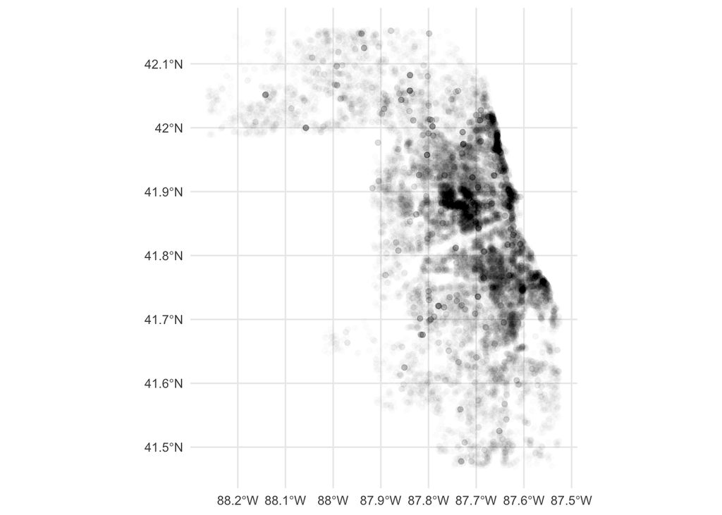

```r
medical %>%
  st_as_sf(coords = c("lon", "lat"), crs = 4326, remove = FALSE) %>%
  ggplot() +
    geom_sf(alpha = 0.01)
```

Using a low value for alpha shows where the majority of deaths reported by the Medical Examiner’s office are located.

### Spatial Joins

The medical examiner data includes someone’s residence zip code. Because we have the spatial data about zip codes, it seems possible to compute those zip codes the actual death occured in. To do this, we need to use a method called a *spatial join*. There are many of these, some of which are quite complex, but the “points in polygon” method here is one of the most common.

The `spatial_join` function takes two datasets and joins them based on their spatial data. The datasets need to be in the same projection; here we convert `ziparea` to lat/lon coordinates. If we join the medical data, converted in spatial points data, into the zip code polygons, we will see which zip area each case occured in:

```r
medical %>%
  st_as_sf(coords = c("lon", "lat"), crs = 4326) %>%
  spatial_join(st_transform(ziparea, 4326)) %>%
  select(residence_zip, zip)
```

```
## Simple feature collection with 34566 features and 2 fields
## geometry type:  POINT
## dimension:      XY
## bbox:           xmin: -88.2625 ymin: 41.46989 xmax: -87.52483 ymax: 42.15345
## geographic CRS: WGS 84
## # A tibble: 34,566 x 3
##    residence_zip zip               geometry
##    <chr>         <chr>          <POINT [°]>
##  1 60644         60644 (-87.77267 41.89388)
##  2 60463         60453 (-87.74232 41.69427)
##  3 60651         60651 (-87.72274 41.90345)
##  4 60005         60005 (-87.99133 42.08584)
##  5 60068         60068 (-87.84851 42.04042)
##  6 60707         60707 (-87.82471 41.93347)
##  7 60636         60636 (-87.67246 41.77301)
##  8 60406         60406  (-87.68496 41.6669)
##  9 60439         60439 (-87.97007 41.65997)
## 10 60455         60455 (-87.81161 41.76887)
## # … with 34,556 more rows
```

Often these are the same, but there are many cases where the two zip codes do not match, as you will see in the Practice questions.

We can also run the join in the other direction, putting the polygon data on the left and the point data on the right. This results in a data set that still contains polygon data.

```r
medical_geo <- medical %>%
  st_as_sf(coords = c("lon", "lat"), crs = 4326, remove = FALSE)

ziparea %>%
  st_transform(4326) %>%
  spatial_join(medical_geo) %>%
  select(residence_zip, zip)
```

```
## Simple feature collection with 35318 features and 2 fields
## geometry type:  MULTIPOLYGON
## dimension:      XY
## bbox:           xmin: -149.964 ymin: 18.13382 xmax: -65.98956 ymax: 61.14823
## geographic CRS: WGS 84
## # A tibble: 35,318 x 3
##    residence_zip zip                                                 geometry
##    <chr>         <chr>                                     <MULTIPOLYGON [°]>
##  1 <NA>          48091 (((-83.08512 42.49076, -83.08205 42.49076, -83.07947 …
##  2 <NA>          56001 (((-94.14327 44.16657, -94.13893 44.1666, -94.13894 4…
##  3 60302         60302 (((-87.80575 41.9089, -87.785 41.90915, -87.7756 41.9…
##  4 60302         60302 (((-87.80575 41.9089, -87.785 41.90915, -87.7756 41.9…
##  5 60302         60302 (((-87.80575 41.9089, -87.785 41.90915, -87.7756 41.9…
##  6 60805         60302 (((-87.80575 41.9089, -87.785 41.90915, -87.7756 41.9…
##  7 60302         60302 (((-87.80575 41.9089, -87.785 41.90915, -87.7756 41.9…
##  8 60098         60302 (((-87.80575 41.9089, -87.785 41.90915, -87.7756 41.9…
##  9 60302         60302 (((-87.80575 41.9089, -87.785 41.90915, -87.7756 41.9…
## 10 60302         60302 (((-87.80575 41.9089, -87.785 41.90915, -87.7756 41.9…
## # … with 35,308 more rows
```

I do not understand why this is the default, but notice that the variables in the second dataset might show up first in the table. You will see that there are some missing values in the dataset. These are zip codes that have no deaths occuring in them. By default, `spatial_join` uses a left spatial join; we can turn that off as follows:

```r
ziparea %>%
  st_transform(4326) %>%
  spatial_join(medical_geo, left = FALSE) %>%
  select(residence_zip, zip)
```

```
## Simple feature collection with 34534 features and 2 fields
## geometry type:  MULTIPOLYGON
## dimension:      XY
## bbox:           xmin: -88.29074 ymin: 41.4116 xmax: -87.52416 ymax: 42.25608
## geographic CRS: WGS 84
## # A tibble: 34,534 x 3
##    residence_zip zip                                                 geometry
##    <chr>         <chr>                                     <MULTIPOLYGON [°]>
##  1 60302         60302 (((-87.80575 41.9089, -87.785 41.90915, -87.7756 41.9…
##  2 60302         60302 (((-87.80575 41.9089, -87.785 41.90915, -87.7756 41.9…
##  3 60302         60302 (((-87.80575 41.9089, -87.785 41.90915, -87.7756 41.9…
##  4 60805         60302 (((-87.80575 41.9089, -87.785 41.90915, -87.7756 41.9…
##  5 60302         60302 (((-87.80575 41.9089, -87.785 41.90915, -87.7756 41.9…
##  6 60098         60302 (((-87.80575 41.9089, -87.785 41.90915, -87.7756 41.9…
##  7 60302         60302 (((-87.80575 41.9089, -87.785 41.90915, -87.7756 41.9…
##  8 60302         60302 (((-87.80575 41.9089, -87.785 41.90915, -87.7756 41.9…
##  9 60302         60302 (((-87.80575 41.9089, -87.785 41.90915, -87.7756 41.9…
## 10 60302         60302 (((-87.80575 41.9089, -87.785 41.90915, -87.7756 41.9…
## # … with 34,524 more rows
```

There are many other kinds of spatial joins that we can run in R, but we will not go into details about them at this time. For example, we can combine two point datasets by matching up each point in one table with the closest point in the second table.

### Distances

Let’s do one more final spatial manipulation of our data. We will make a spatial dataset with a single row corresponding to Millennium Park in downtown Chicago:

```r
millennium_park <- tibble(lon = -87.6243107, lat = 41.882612) %>%
  st_as_sf(coords = c("lon", "lat"), crs = 4326)
millennium_park
```

```
## Simple feature collection with 1 feature and 0 fields
## geometry type:  POINT
## dimension:      XY
## bbox:           xmin: -87.62431 ymin: 41.88261 xmax: -87.62431 ymax: 41.88261
## geographic CRS: WGS 84
## # A tibble: 1 x 1
##               geometry
## *          <POINT [°]>
## 1 (-87.62431 41.88261)
```

The reason for creating this data point is to compute the distance from all of the medical cases to the center of the park. The computation for this looks similar to the `st_area` function we saw last time. The results are returned in metres, which we convert to kilometres by dividing by 1000.

```r
medical_geo %>%
  mutate(distance_mp = as.numeric(st_distance(geometry, millennium_park)) / 1000)
```

```
## Simple feature collection with 34566 features and 15 fields
## geometry type:  POINT
## dimension:      XY
## bbox:           xmin: -88.2625 ymin: 41.46989 xmax: -87.52483 ymax: 42.15345
## geographic CRS: WGS 84
## # A tibble: 34,566 x 16
##    date_incident_iso   date_death_iso      primary_cause   age gender race
##  * <dttm>              <dttm>              <chr>         <dbl> <chr>  <chr>
##  1 2015-01-01 03:25:00 2015-01-01 03:10:00 HYPERTENSIVE…    50 Male   Black
##  2 2014-12-08 18:37:00 2015-01-01 07:15:00 COMPLICATION…    89 Female White
##  3 2014-12-21 23:13:00 2015-01-01 08:45:00 COMPLICATION…    67 Male   Black
##  4 2015-01-01 09:07:00 2015-01-01 09:20:00 COMPLICATION…    31 Male   White
##  5 2015-01-01 09:54:00 2015-01-01 10:10:00 ASPHYXIATION     25 Male   White
##  6 2015-01-01 10:45:00 2015-01-01 11:19:00 HYPERTENSIVE…    71 Male   White
##  7 2015-01-01 10:43:00 2015-01-01 11:22:00 DIABETIC KET…    61 Female Black
##  8 2015-01-01 12:00:00 2015-01-01 13:18:00 ALCOHOL TOXI…    26 Male   White
##  9 2015-01-01 15:14:00 2015-01-01 15:30:00 ARTERIOSCLER…    56 Male   White
## 10 2015-01-01 15:27:00 2015-01-01 15:45:00 CHRONIC OBST…    81 Female White
## # … with 34,556 more rows, and 10 more variables: latino <lgl>,
## #   gun_related <lgl>, opioid_related <lgl>, cold_related <lgl>,
## #   heat_related <lgl>, lon <dbl>, lat <dbl>, residence_zip <chr>,
## #   geometry <POINT [°]>, distance_mp <dbl>
```

One application of this technique is to filter the data to only include points in a particular part of the world. Here, we look at just the deaths that occured near the Park:

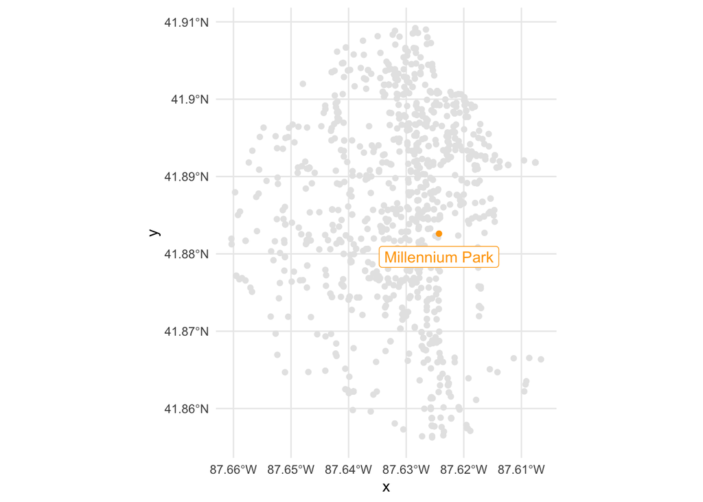

```r
medical_geo %>%
  mutate(distance_mp = as.numeric(st_distance(geometry, millennium_park)) / 1000) %>%
  filter(distance_mp < 3) %>%
  ggplot() +
    geom_sf(color = "grey90") +
    geom_sf(color = "orange", data = millennium_park) +
    geom_sf_label(
      label = "Millennium Park",
      color = "orange",
      data = millennium_park,
      nudge_y = -0.003
    )
```

You can see that it roughly maps out a circle (there is a lake to the East of the city).

### Raster Graphics (Maptiles)

To wrap up our spatial methods, let’s look at something completely different. Rather than working with precise regions (vector data), it can often be useful to instead plot spatial data over a map. This map could be something similar to the maps used in Apple Maps or Google Maps. To start, let’s take only a set of points that are very close to the park:

```r
medical_mp <- medical_geo %>%
  mutate(distance_mp = as.numeric(st_distance(geometry, millennium_park)) / 1000) %>%
  filter(distance_mp < 1.5)
```

In order to show these over a map, we simply use a scatter plot (NOT `geom_sf`) on top of a special layer called `stat_maptiles`. Note that the map times need to go first, otherwise they will be plotted on top of the points. We can set the opacity (alpha) of the times to make the data easier to see.

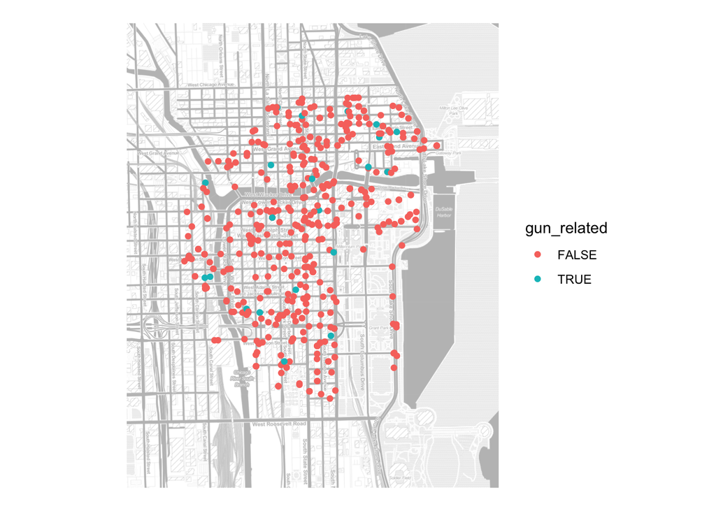

```r
medical_mp %>%
  ggplot(aes(lon, lat)) +
    stat_maptiles(alpha = 0.3) +
    geom_point(aes(color = gun_related)) +
    theme_void()
```

There are many other options that you can tweak with the maptiles. See the link on the course website for more details.

## Practice

Pick a location in Chicago other than Millennium Park. Subset the medical data to within 1km of this location and plot the locations of the deaths over a map. Color the points according the race of the deceased.

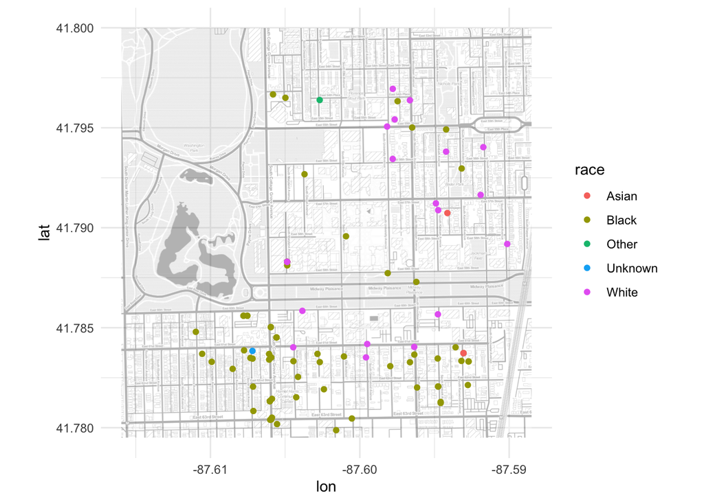

```r
u_chicago <- tibble(lon = -87.6009667, lat = 41.788452) %>%
  st_as_sf(coords = c("lon", "lat"), crs = 4326)

medical_geo %>%
  mutate(distance_mp = as.numeric(st_distance(geometry, u_chicago)) / 1000) %>%
  filter(distance_mp < 1) %>%
  ggplot(aes(lon, lat)) +
    stat_maptiles(alpha = 0.3) +
    geom_point(aes(color = race))
```

Draw a map of the zip codes data showing the number of opiod deaths that occurred in each zip code. Try to use a good color scale.

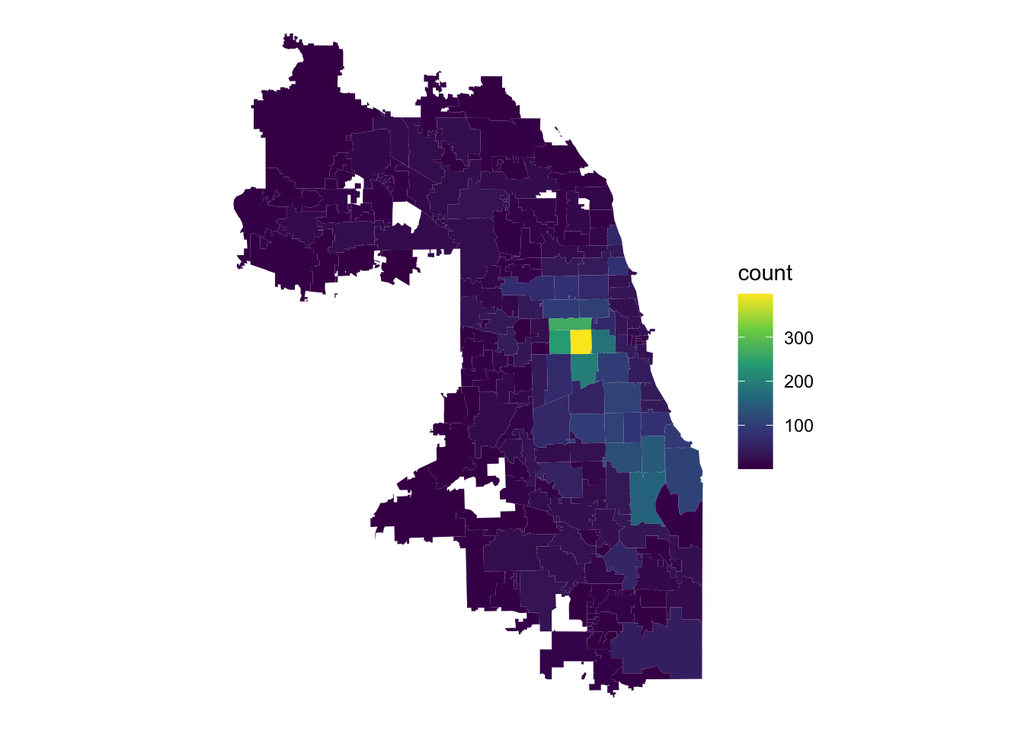

```r
ziparea %>%
  st_transform(4326) %>%
  spatial_join(medical_geo, left = FALSE) %>%
  filter(opioid_related) %>%
  group_by(zip) %>%
  summarize(sm_count()) %>%
  ggplot() +
    geom_sf(aes(fill = count), size = 0) +
    scale_fill_viridis_c() +
    theme_void()
```

There is another spatial dataset included here giving the community area in Chicago. Repeat the previous question with these regions.

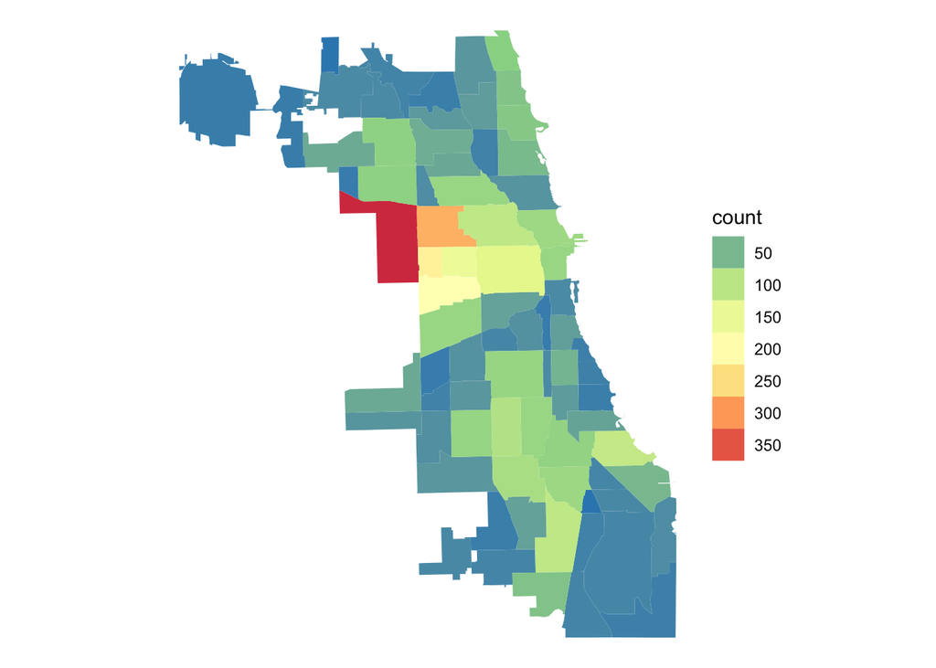

```r
comarea %>%
  st_transform(4326) %>%
  spatial_join(medical_geo, left = FALSE) %>%
  filter(opioid_related) %>%
  group_by(comarea_name) %>%
  summarize(sm_count()) %>%
  ggplot() +
    geom_sf(aes(fill = count), size = 0) +
    scale_fill_distiller(palette = "Spectral", guide = "legend", n.breaks = 10) +
    theme_void()
```

One advantage of the community areas is that we have socioeconomic covariates available in the data associated with each region. Draw a scatter plot with one point for each community area, showing the median income on the x-axis and the number of opioid deaths on the y-axis. Using labels to indicate the names of the community areas.

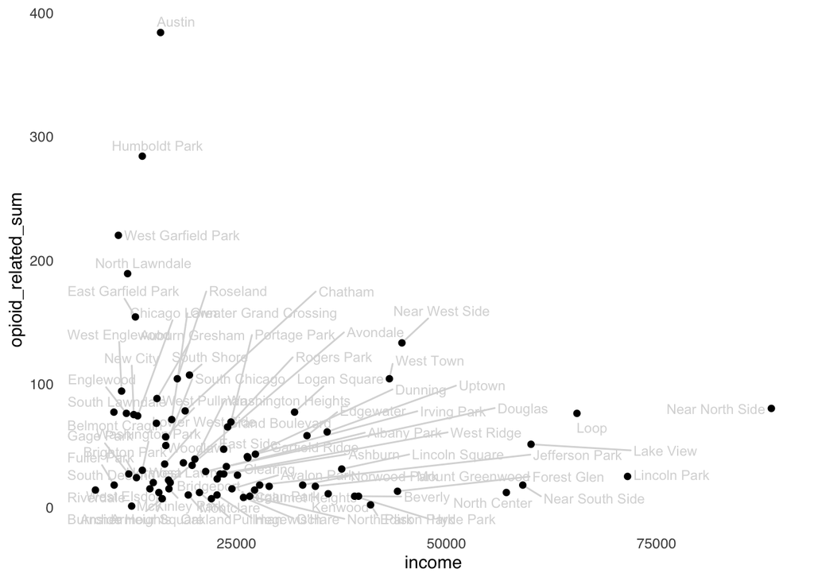

```r
medical_geo %>%
  spatial_join(st_transform(comarea, 4326), left = FALSE) %>%
  group_by(comarea, comarea_name) %>%
  summarise(sm_sum(opioid_related)) %>%
  left_join(socio, by = c("comarea", "comarea_name")) %>%
  ggplot(aes(income, opioid_related_sum)) +
    geom_text_repel(aes(label = comarea_name), size = 3, color = "grey85") +
    geom_point() +
    theme_sm()
```

```
## although coordinates are longitude/latitude, st_intersects assumes that they are planar
## although coordinates are longitude/latitude, st_intersects assumes that they are planar
```

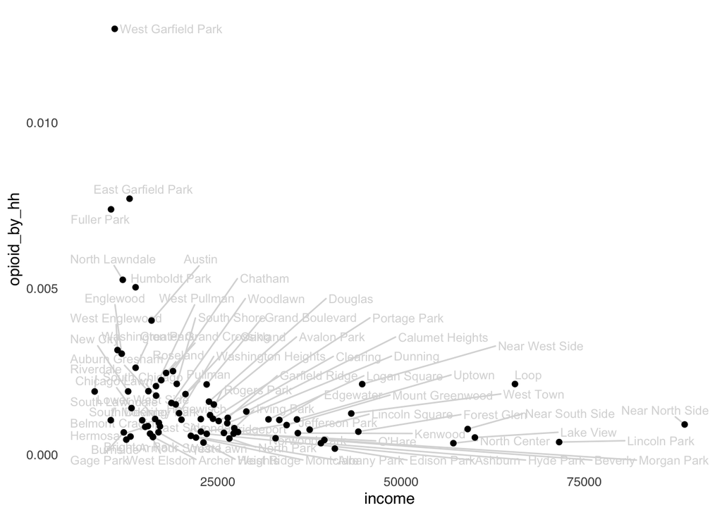

```r
medical_geo %>%
  spatial_join(st_transform(comarea, 4326), left = FALSE) %>%
  group_by(comarea, comarea_name) %>%
  summarise(sm_sum(opioid_related)) %>%
  left_join(socio, by = c("comarea", "comarea_name")) %>%
  mutate(opioid_by_hh = opioid_related_sum / population) %>%
  ggplot(aes(income, opioid_by_hh)) +
    geom_text_repel(aes(label = comarea_name), size = 3, color = "grey85") +
    geom_point() +
    theme_sm()
```